# 14 - Proportions and enrichment

# Exercise

## Chi-squared goodness of fit test

You did two crosses. You crossed a Aa mother to a AA father, you got 30 Aa and 60 AA. You crossed a AA mother to a Aa father, you got 55 Aa and 50 AA. (The expected proportions should be 1:1.)

Is there distortion of segregation ratio in either of the crosses? If so, which parent is the defect associated with?

```r
# You will need to do two chisq.tests. put them here.
chisq.test(x = c(30, 60), p = c(0.5, 0.5))
```

```
##
##  Chi-squared test for given probabilities
##
## data:  c(30, 60)
## X-squared = 10, df = 1, p-value = 0.001565
```

```r
chisq.test(x = c(55, 50), p = c(0.5, 0.5))
```

```
##
##  Chi-squared test for given probabilities
##
## data:  c(55, 50)
## X-squared = 0.2381, df = 1, p-value = 0.6256
```

Now let’s look at the built in dataset diamonds, and see if there is a difference in the cut and color variables.

```r
# Load the diamonds dataset
data(diamonds)

# View the first few rows of the dataset
head(diamonds)
```

```
## # A tibble: 6 × 10
##   carat cut       color clarity depth table price     x     y     z
##   <dbl> <ord>     <ord> <ord>   <dbl> <dbl> <int> <dbl> <dbl> <dbl>
## 1  0.23 Ideal     E     SI2      61.5    55   326  3.95  3.98  2.43
## 2  0.21 Premium   E     SI1      59.8    61   326  3.89  3.84  2.31
## 3  0.23 Good      E     VS1      56.9    65   327  4.05  4.07  2.31
## 4  0.29 Premium   I     VS2      62.4    58   334  4.2   4.23  2.63
## 5  0.31 Good      J     SI2      63.3    58   335  4.34  4.35  2.75
## 6  0.24 Very Good J     VVS2     62.8    57   336  3.94  3.96  2.48
```

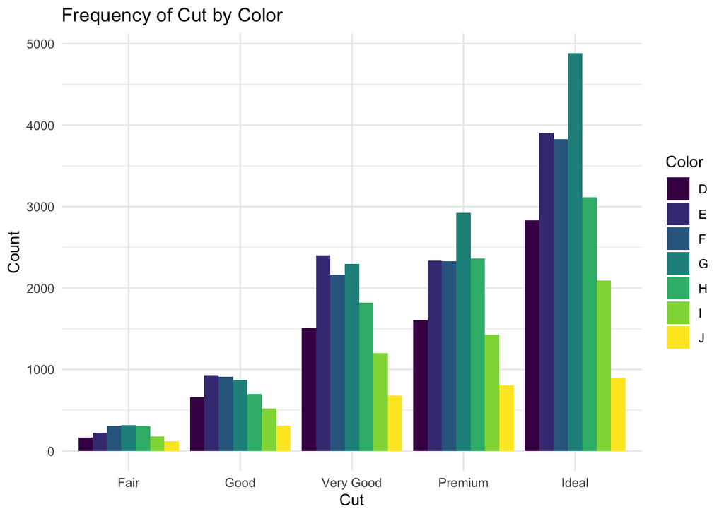

```r
# Plot the frequency of cut and color. I recommend using ggplot2 and 'geom_bar'

ggplot(diamonds, aes(x = cut, fill = color)) +
  geom_bar(position = "dodge") +
  labs(
    title = "Frequency of Cut by Color",
    x = "Cut",
    y = "Count",
    fill = "Color"
  ) +
  theme_minimal()
```

```r
# Perform Chi-square test


# Print the result
# Create contingency table
diamonds_table <- with(diamonds, table(cut, color))

# Perform chi-square test
chi_res_diamonds <- chisq.test(diamonds_table)

# View results
chi_res_diamonds
```

```
##
##  Pearson's Chi-squared test
##
## data:  diamonds_table
## X-squared = 310.32, df = 24, p-value < 2.2e-16
```

## What to submit to Moodle (Pass/Fail)

For this lesson, complete the exercises **in your shared Exercise Pack** (the file `Exercise_Pack_Template.Rmd`). Then **Knit to HTML** and upload the HTML file to the Moodle exercise folder.

**File name format:** `Lastname_Firstname_L14.html`

### Satisfactory / Not satisfactory (what I check)

Your submission is **Satisfactory** if:

- It **knits** (HTML opens and shows your work).
- You included **outputs** (plots/tables/model output) that match the lesson.
- You answered the **Self-check checklist** (short, honest, and complete).
- Your work is **plausible** (right method for the lesson, correct variables, no obvious copy/paste without results).

### Exercise 2 — Two proportions test

Compare two proportions (chi-square or Fisher’s exact, depending on counts). Interpret the result.

**Self-check:** you show a 2x2 table and the test output.

### Exercise 3 — Odds ratio (manual check)

Compute an odds ratio from a 2x2 table (either using a function or by hand). Confirm it matches (approximately) what the test reports.

```r
fisher.test(x = rbind(c(33, 14),
                      c(23,5)))
```

```
##
##  Fisher's Exact Test for Count Data
##
## data:  rbind(c(33, 14), c(23, 5))
## p-value = 0.2861
## alternative hypothesis: true odds ratio is not equal to 1
## 95 percent confidence interval:
##  0.1274448 1.7950771
## sample estimates:
## odds ratio
##  0.5168263
```

```r
(33/23)/(14/5)
```

```
## [1] 0.5124224
```

**Self-check:** manual OR and reported OR are close; you show your calculation.

### Exercise 4 — Enrichment idea

Run (or simulate) a simple enrichment-style test (hypergeometric framing is fine). Explain what “enriched” means in your context. (Typical use case gene set enrichment)

if necessary I can just do some DNA encoded library example where e.g. certain moieties are enriched after the experiment (or use gemini to generate the values for us). Note that sequences represent DNA barcodes attached to chemical building blocks. Prompt: simulate a small DNA encoded library experiment. Row 1: count of a few different sequences. Row2: count of sequences after the assay then calculate chi-square and fishers exact test

```r
# Create the contingency table
# Each column is a sequence, Each row is a stage
del_matrix <- matrix(c(250, 40,   # Seq_A
                       260, 35,   # Seq_B
                       240, 100,  # Seq_C
                       250, 45),  # Seq_D
                     nrow = 2,
                     dimnames = list(Stage = c("Input", "Assay"),
                                     Sequence = c("Seq_A", "Seq_B", "Seq_C", "Seq_D")))

# 1. Chi-Square Test
chi_result <- chisq.test(del_matrix)

# 2. Fisher's Exact Test
# (Note: For very large tables, simulate.p.value = TRUE may be needed)
#fisher_result <- fisher.test(del_matrix, simulate.p.value = T)

# View Results
print(chi_result)
```

```
##
##  Pearson's Chi-squared test
##
## data:  del_matrix
## X-squared = 42.445, df = 3, p-value = 3.228e-09
```

```r
#print(fisher_result)
```

**Self-check:** you define background vs selected set clearly.

### Exercise 5 — Visualization

Make a clear bar plot (with uncertainty if possible) for proportions and annotate with group sizes.

```r
library(scales)
```

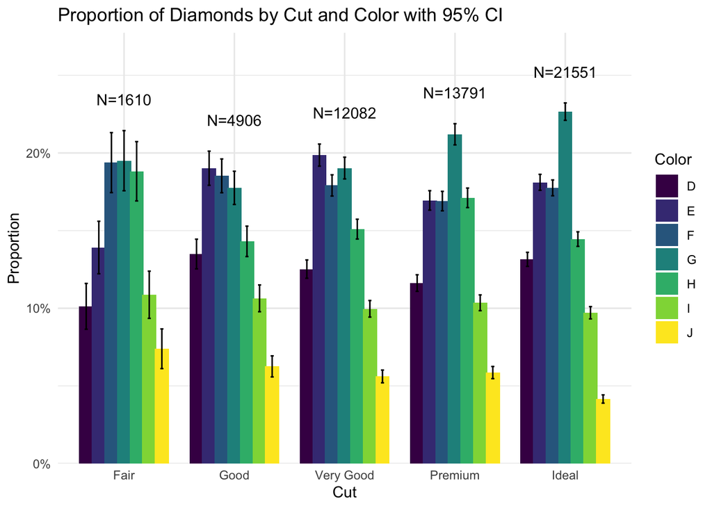

```r
# compute proportions, SE, and 95% CI by cut and color
df_prop <- diamonds %>%
  count(cut, color) %>%
  group_by(cut) %>%
  mutate(
    N     = sum(n),
    prop  = n / N,
    se    = sqrt(prop * (1 - prop) / N),
    lower = prop - 1.96 * se,
    upper = prop + 1.96 * se
  ) %>%
  ungroup()

# compute total N and max upper per cut for annotation
df_N <- df_prop %>%
  group_by(cut) %>%
  summarise(
    N_total = first(N),
    ymax    = max(upper)
  ) %>%
  ungroup()

# plot
ggplot(df_prop, aes(x = cut, y = prop, fill = color)) +
  geom_col(position = position_dodge(width = 0.8)) +
  geom_errorbar(aes(ymin = lower, ymax = upper),
                position = position_dodge(width = 0.8),
                width = 0.2) +
  geom_text(data = df_N,
            aes(x = cut, y = ymax + 0.02, label = paste0("N=", N_total)),
            inherit.aes = FALSE) +
  scale_y_continuous(labels = percent_format(), expand = expansion(mult = c(0, 0.1))) +
  labs(
    title = "Proportion of Diamonds by Cut and Color with 95% CI",
    x = "Cut",
    y = "Proportion",
    fill = "Color"
  ) +
  theme_minimal()
```

**Self-check:** plot shows proportions (0–1 or 0–100%) and includes n.